# Red Wine Quality EDA

```r
# Load the Data
red_df <- read.csv("wineQualityReds.csv")
```

```
##   X fixed.acidity volatile.acidity citric.acid residual.sugar chlorides
## 1 1           7.4             0.70        0.00            1.9     0.076
## 2 2           7.8             0.88        0.00            2.6     0.098
## 3 3           7.8             0.76        0.04            2.3     0.092
##   free.sulfur.dioxide total.sulfur.dioxide density   pH sulphates alcohol
## 1                  11                   34  0.9978 3.51      0.56     9.4
## 2                  25                   67  0.9968 3.20      0.68     9.8
## 3                  15                   54  0.9970 3.26      0.65     9.8
##   quality
## 1       5
## 2       5
## 3       5
```

```
##
## Data Dimensions:  1599 13
##
## Columns Names:
##  X fixed.acidity volatile.acidity citric.acid residual.sugar chlorides free.sulfur.dioxide total.sulfur.dioxide density pH sulphates alcohol quality
##
## Checking for any missing values:  FALSE
```

```r
# Dropping the x column as it's just for indexing and unnecessary in analysis
# and there is automatic indexing in r

red_df = red_df[, c(2: length(red_df))]
head(red_df, 3)
```

```
##   fixed.acidity volatile.acidity citric.acid residual.sugar chlorides
## 1           7.4             0.70        0.00            1.9     0.076
## 2           7.8             0.88        0.00            2.6     0.098
## 3           7.8             0.76        0.04            2.3     0.092
##   free.sulfur.dioxide total.sulfur.dioxide density   pH sulphates alcohol
## 1                  11                   34  0.9978 3.51      0.56     9.4
## 2                  25                   67  0.9968 3.20      0.68     9.8
## 3                  15                   54  0.9970 3.26      0.65     9.8
##   quality
## 1       5
## 2       5
## 3       5
```

> This data set presents the quality of red wine along with a set of factors that contribute to the final quality like alcohol content and acids. The dataset consist of 1599 observations over 12 variables with quality as ordinal categorical variable. The data contains no missing values and all other variables, aside from quality, are numerical

# Univariate Plots Section

```
## 'data.frame':    1599 obs. of  12 variables:
##  $ fixed.acidity       : num  7.4 7.8 7.8 11.2 7.4 7.4 7.9 7.3 7.8 7.5 ...
##  $ volatile.acidity    : num  0.7 0.88 0.76 0.28 0.7 0.66 0.6 0.65 0.58 0.5 ...
##  $ citric.acid         : num  0 0 0.04 0.56 0 0 0.06 0 0.02 0.36 ...
##  $ residual.sugar      : num  1.9 2.6 2.3 1.9 1.9 1.8 1.6 1.2 2 6.1 ...
##  $ chlorides           : num  0.076 0.098 0.092 0.075 0.076 0.075 0.069 0.065 0.073 0.071 ...
##  $ free.sulfur.dioxide : num  11 25 15 17 11 13 15 15 9 17 ...
##  $ total.sulfur.dioxide: num  34 67 54 60 34 40 59 21 18 102 ...
##  $ density             : num  0.998 0.997 0.997 0.998 0.998 ...
##  $ pH                  : num  3.51 3.2 3.26 3.16 3.51 3.51 3.3 3.39 3.36 3.35 ...
##  $ sulphates           : num  0.56 0.68 0.65 0.58 0.56 0.56 0.46 0.47 0.57 0.8 ...
##  $ alcohol             : num  9.4 9.8 9.8 9.8 9.4 9.4 9.4 10 9.5 10.5 ...
##  $ quality             : int  5 5 5 6 5 5 5 7 7 5 ...
```

```r
## Converting quality column to an ordered factor

red_df$quality = ordered(red_df$quality)
```

> Data Summary

```
##  fixed.acidity   volatile.acidity  citric.acid    residual.sugar
##  Min.   : 4.60   Min.   :0.1200   Min.   :0.000   Min.   : 0.900
##  1st Qu.: 7.10   1st Qu.:0.3900   1st Qu.:0.090   1st Qu.: 1.900
##  Median : 7.90   Median :0.5200   Median :0.260   Median : 2.200
##  Mean   : 8.32   Mean   :0.5278   Mean   :0.271   Mean   : 2.539
##  3rd Qu.: 9.20   3rd Qu.:0.6400   3rd Qu.:0.420   3rd Qu.: 2.600
##  Max.   :15.90   Max.   :1.5800   Max.   :1.000   Max.   :15.500
##    chlorides       free.sulfur.dioxide total.sulfur.dioxide
##  Min.   :0.01200   Min.   : 1.00       Min.   :  6.00
##  1st Qu.:0.07000   1st Qu.: 7.00       1st Qu.: 22.00
##  Median :0.07900   Median :14.00       Median : 38.00
##  Mean   :0.08747   Mean   :15.87       Mean   : 46.47
##  3rd Qu.:0.09000   3rd Qu.:21.00       3rd Qu.: 62.00
##  Max.   :0.61100   Max.   :72.00       Max.   :289.00
##     density             pH          sulphates         alcohol
##  Min.   :0.9901   Min.   :2.740   Min.   :0.3300   Min.   : 8.40
##  1st Qu.:0.9956   1st Qu.:3.210   1st Qu.:0.5500   1st Qu.: 9.50
##  Median :0.9968   Median :3.310   Median :0.6200   Median :10.20
##  Mean   :0.9967   Mean   :3.311   Mean   :0.6581   Mean   :10.42
##  3rd Qu.:0.9978   3rd Qu.:3.400   3rd Qu.:0.7300   3rd Qu.:11.10
##  Max.   :1.0037   Max.   :4.010   Max.   :2.0000   Max.   :14.90
```

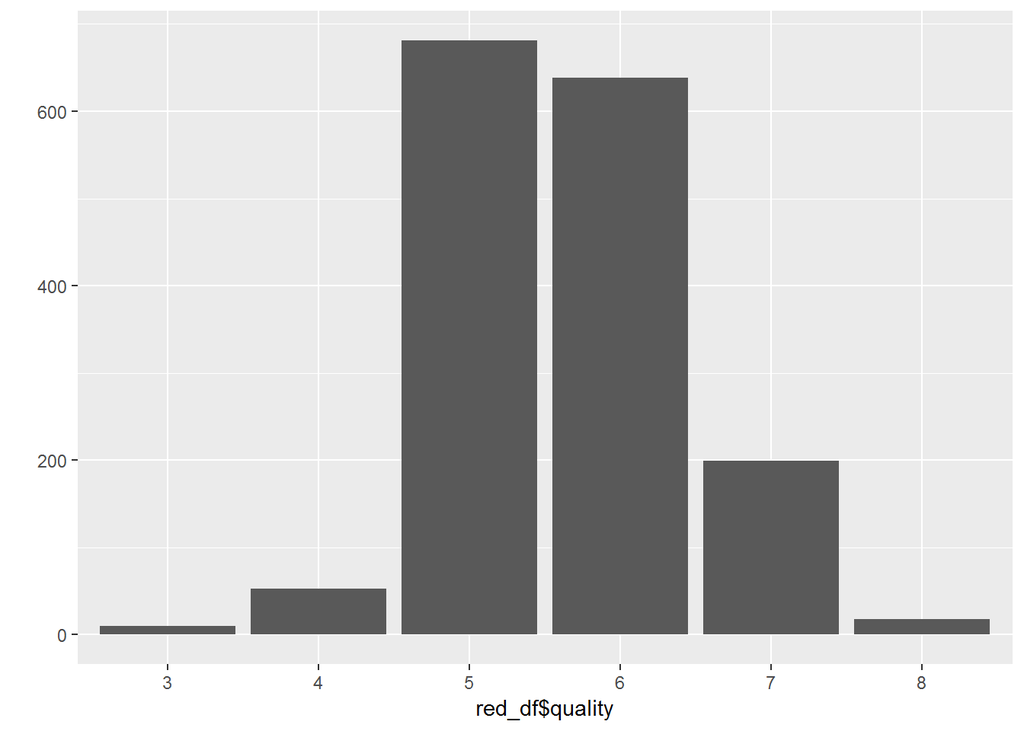

Although the possible values of quality range from 0 to 10, it seems that taking the median value from multiple expert rating to the same wine biased the quality ratings to be confined to 3, 4, 5, 6, 7, 8 values and giving this distribution shape where most ratings fall to 5, 6, 7 ratings

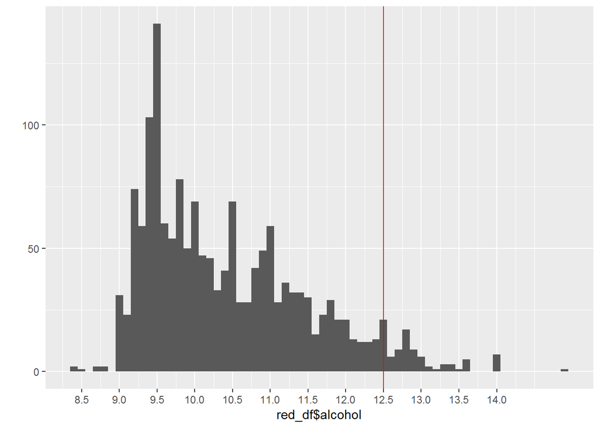

There is a that trend of repeating concentrated count around some values shown by the peak spikes-like bins, for example around 9.5, 10, 10.5, 11 and that’s maybe due to some bias resulted from the process of making wine. For example, The wine makers may favour some alcohol concentrations over others for commercial, economical, even tax driven purposes, so we should return to the wine manifacturers to make sure of this.

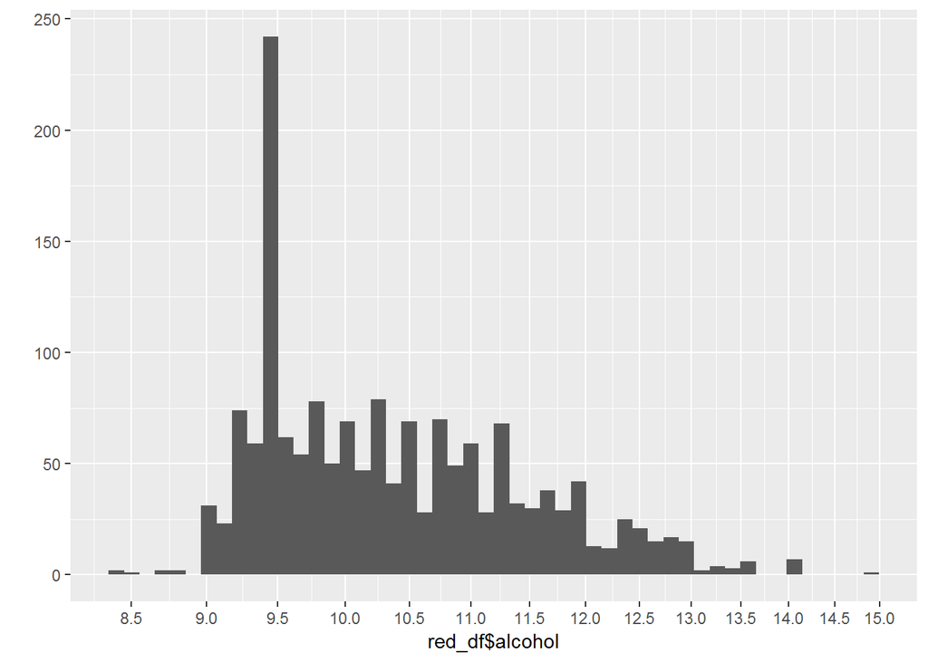

Data still slightly positive skewed due to the modal left peak which now grow even taller as the values of multiple bins in the original histogram were mapped through the log10() transformation function to the same bin. The spiky bins trend preserves, but instead of a staircase descending manner, now it’s almost uniform, all peaks around 75 counts

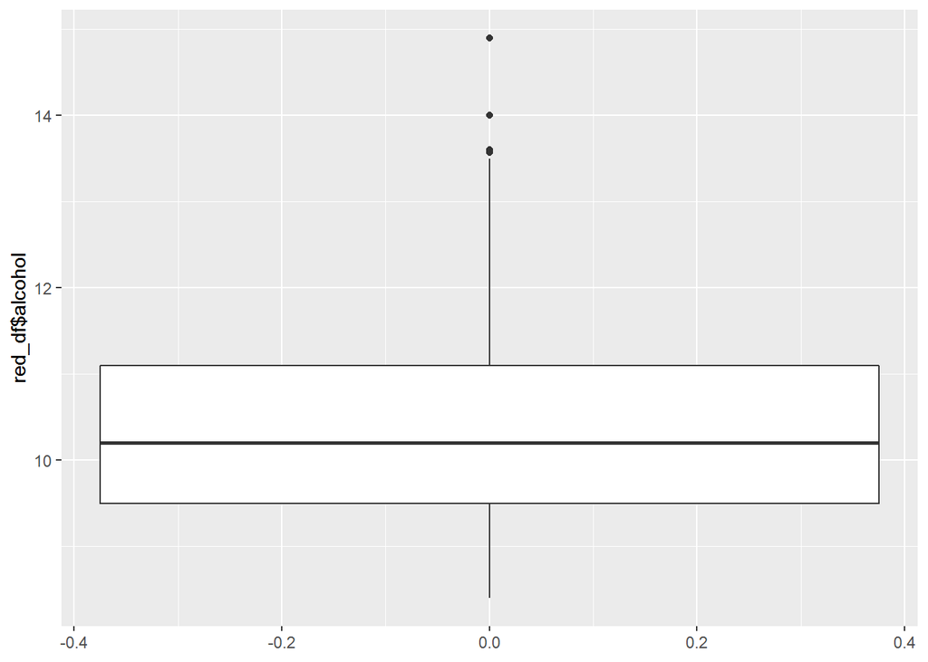

The boxplot reaffirms outliers with alcohol more than 13 and point out that bulk of the data lies between 9.5 and 11.2 approximately

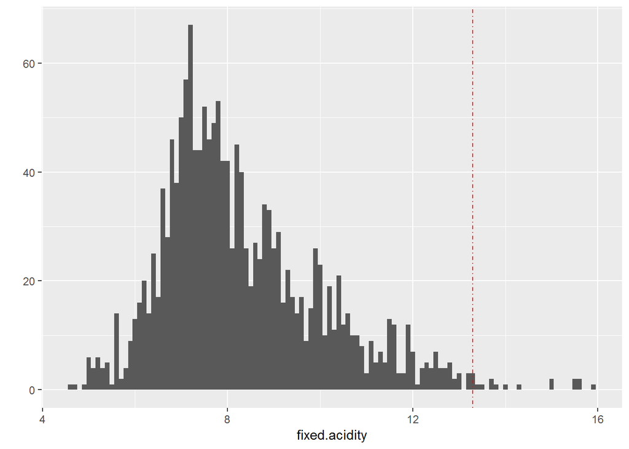

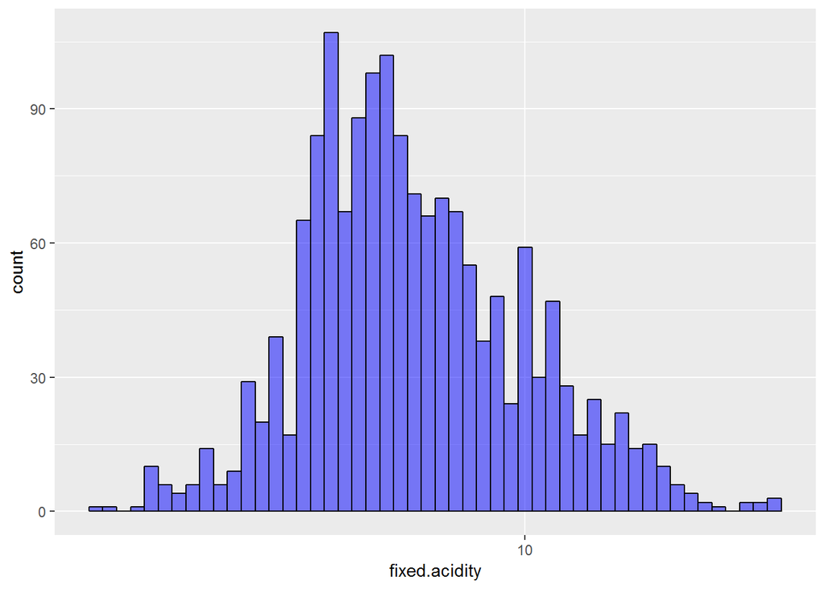

The fixed acidity Dist. is right skewed, but after applying log10 transformation in the blue histogram, it’s now normalized to some extent, which can be useful in later analysis when applying a regression model (logistic)

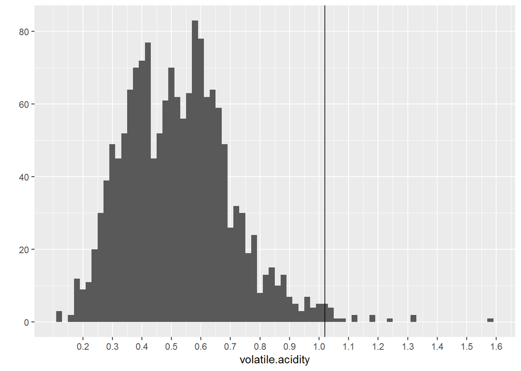

The Dist. is bimodal where the most volatile acidity concentrations used are found to be in the vacinity of .4 and .6 respectively

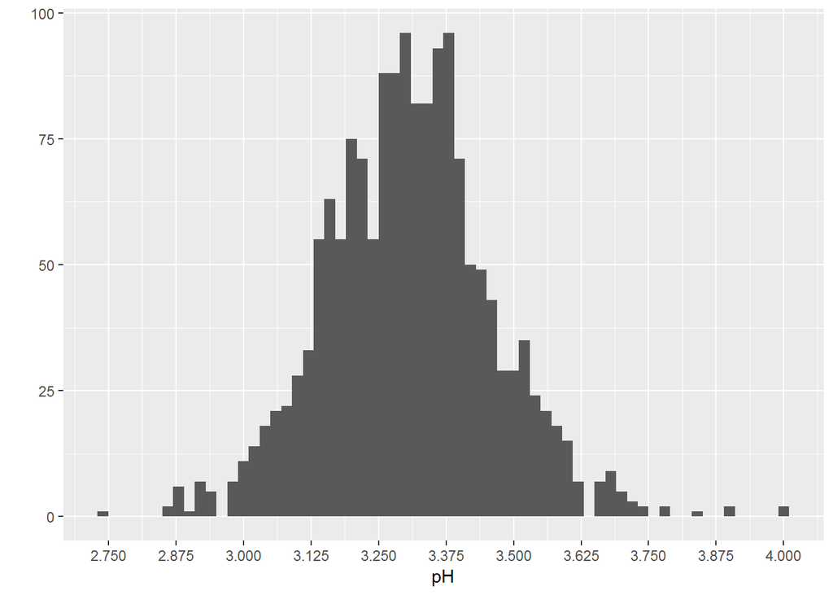

ph distribution seems normal, pH concentrations more than 3.625 or less than 3 seem to be rare in red wines, the most concentration lies around 3.375

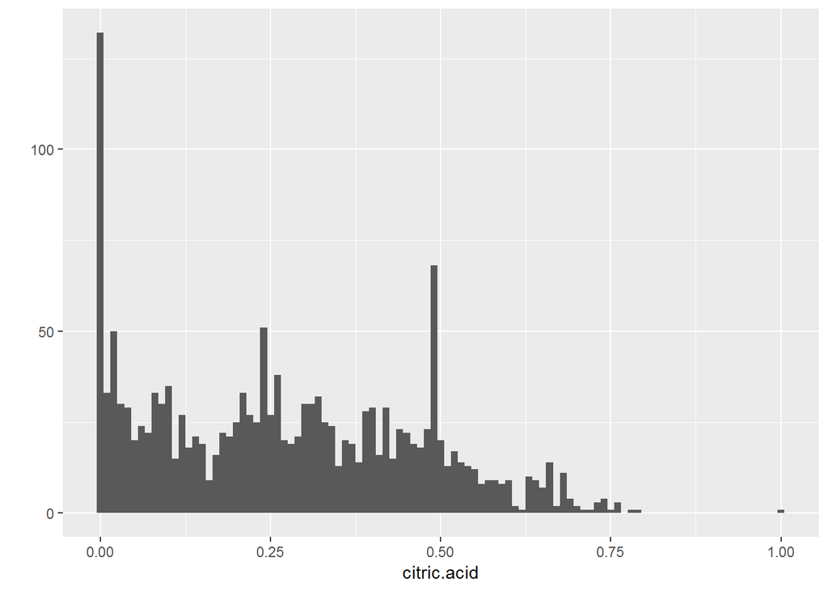

The concentration of citric.acid is very low and we can observe this in the towering first bin from 0 to .01, there is also moderate to high frequecy of citric.acid among wines for concentrations below .5. Concentration of 1 is an obvious outlier

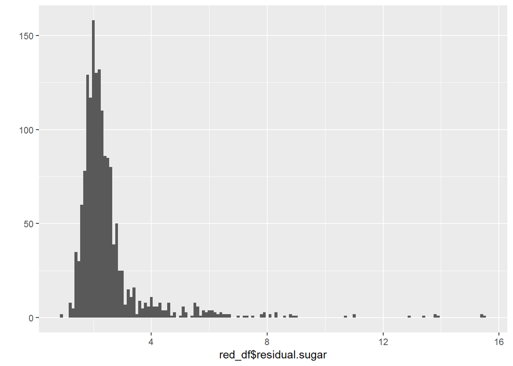

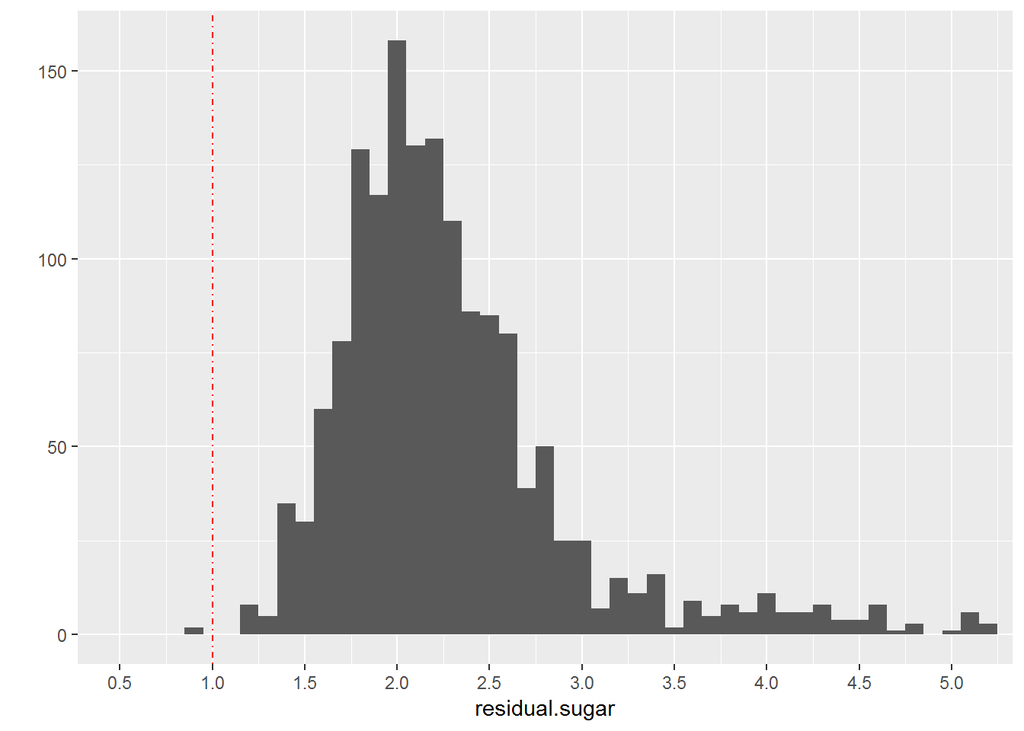

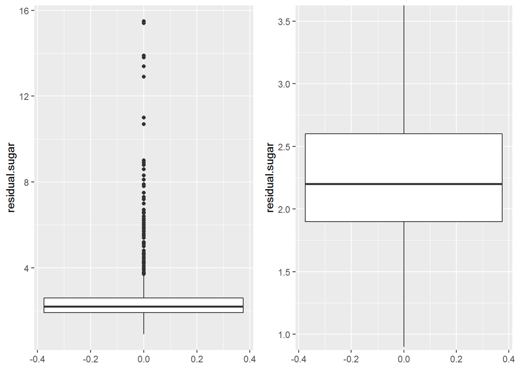

Affirmed by the boxplot, the bulk of the data is between 1.5 and 3 approximately, and the distribution of residual.sugar in this area, is pretty normal as appears in the boxplot of seemingly same length second and third quartiles and affirmed by the shape of the histogram distribution in this particular area. Sugar content greater than 4, isn’t a common practice among red wine makers from our sample

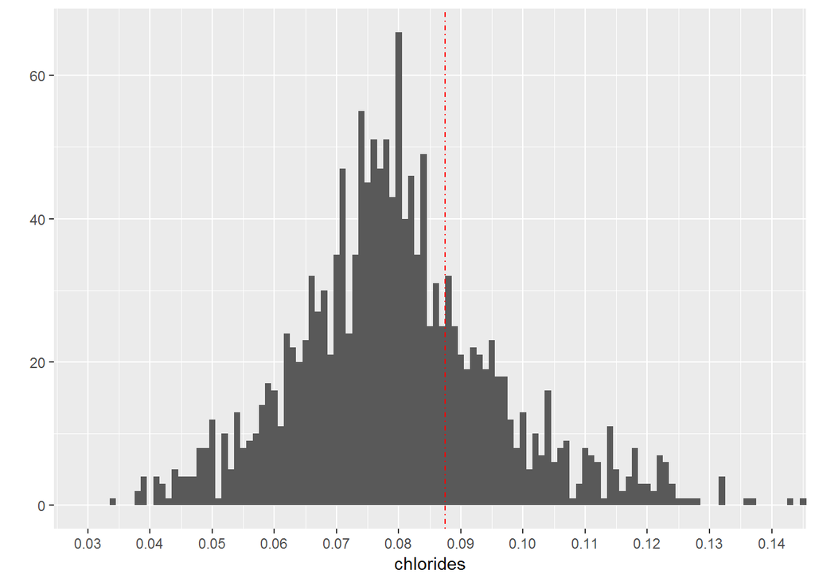

```
##
## Chlorides outliers pecentage:  4.627892 %
```

Chlorides concentrates between .03 and .14, concentrations with values outside this region are rare like the one at .01 (not visible in the plot) or those larger than .14, those outside this region combined are less shan 5% of the data ***

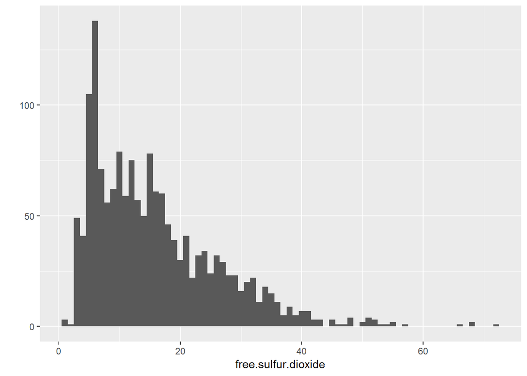

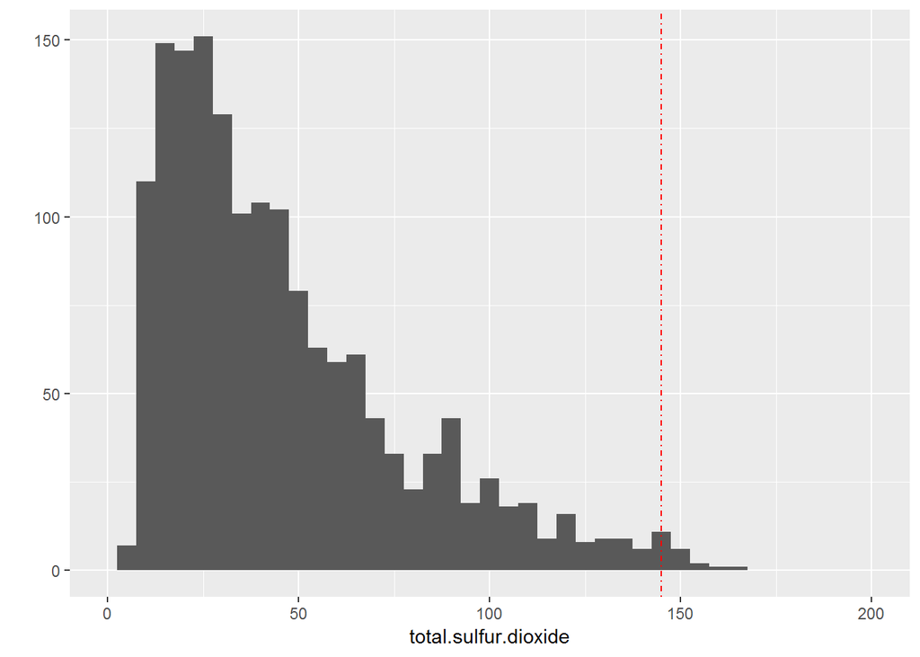

Both free.sulful.dioxide and total.sulfur.dioxide are right-skewed, that may not come as a surprise as free.sulful.dioxide is supposedly part of the total.sulfur.dioxide where total.sulfur.dioxide covers both the free molecular formed SO2 and the bound ones.

> Since both TSO2 and FSO2 are related, we may measure the ratio of the free sulfur dioxide with respect to TSO2, taking the ratio may remove the skewness and be better representative in modeling in multivariate analysis afterwads

```r
## The vertical line represents water density

red_df$free.sulfur.dioxide.ratio = red_df$free.sulfur.dioxide / red_df$total.sulfur.dioxide

summary(red_df$free.sulfur.dioxide.ratio)
```

```
##    Min. 1st Qu.  Median    Mean 3rd Qu.    Max.
## 0.02273 0.25926 0.37500 0.38231 0.48485 0.85714
```

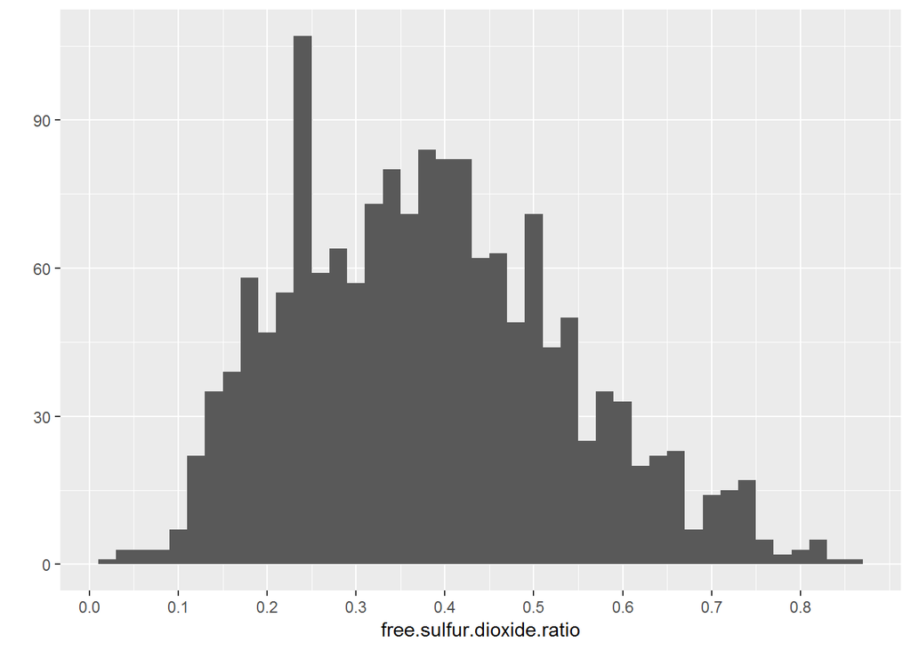

```r
qplot(data = red_df, free.sulfur.dioxide.ratio, binwidth = .02)+
  scale_x_continuous(breaks = seq(0, .8, .1))
```

A maximum of .85714 < 1 of free.sulur.dioxide.ratio and a minimum greater than 0 verifies logically that there are no seemingly incorrect data in our dataset as the free.sulfur.dioxide concentration should always be less than the total sulfur dioxide and a cocentration of zero may not be correct because free sulfur dioxide is responsible for killing bacteria

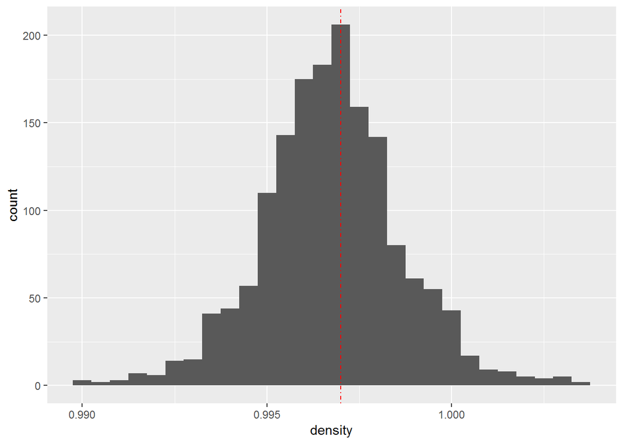

red wine density is normally distributed around water density which is about .997 as indicaed by the vertical line

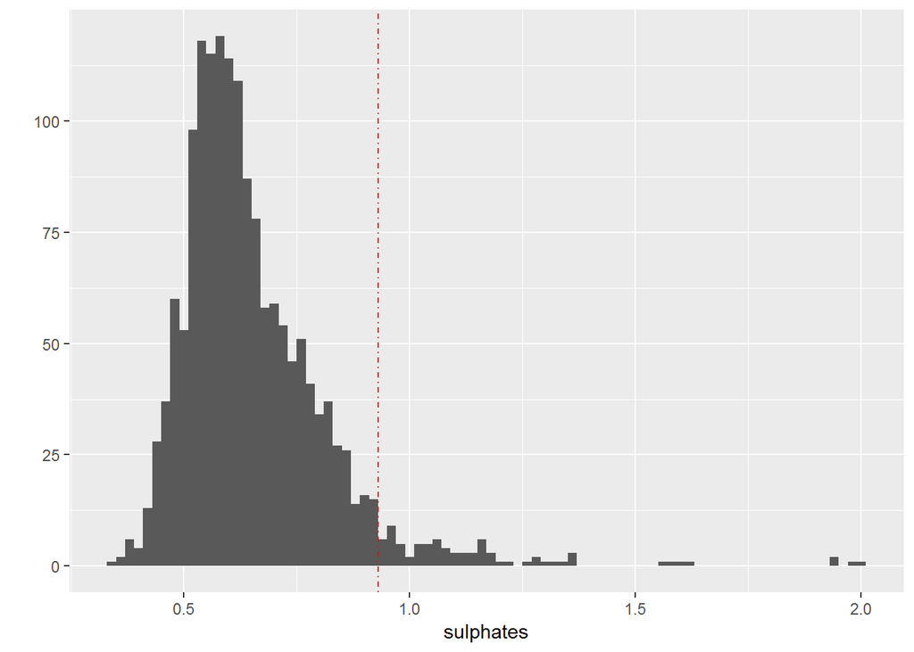

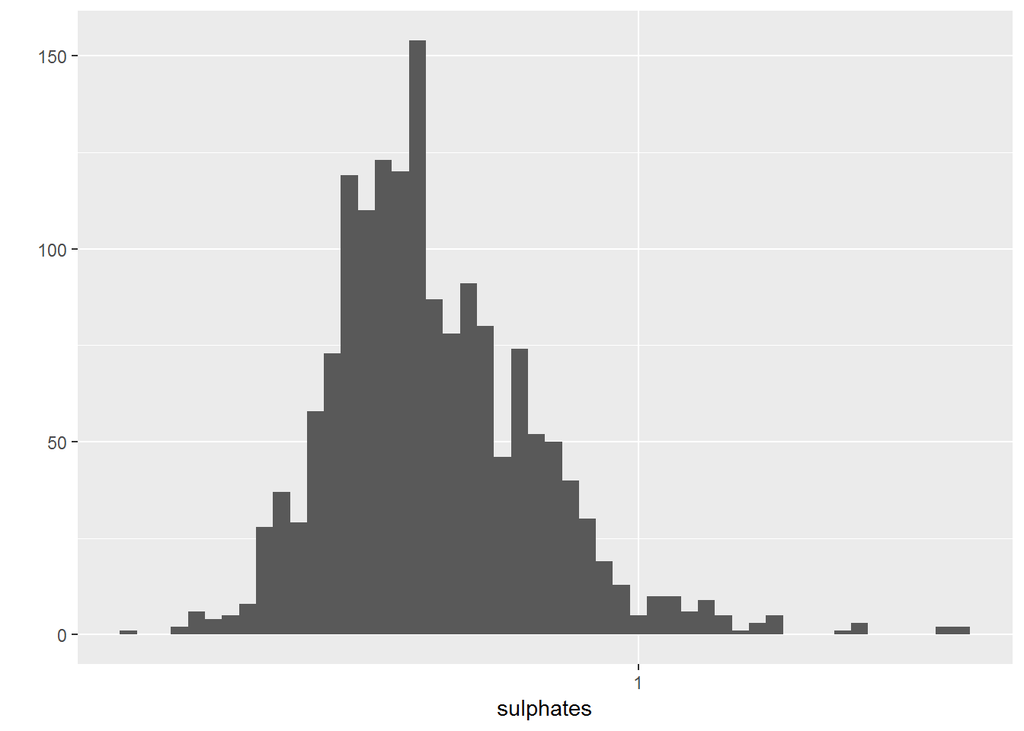

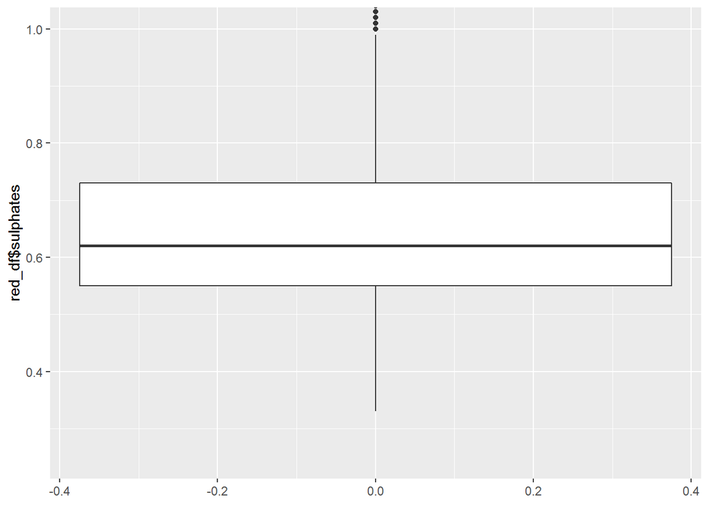

slightly right skewed with outliers, zooming and log transformaing slightly lessens the skewness as seen above. Sulphates concentrations more than 1 considered outliers

# Univariate Analysis

### What is the structure of your dataset?

The dataset consists of 1599 observations over 12 main features (“fixed.acidity”, “volatile.acidity”, “citric.acid”, “residual.sugar”, “chlorides”, “free.sulfur.dioxide”, “total.sulfur.dioxide”, “density”, “pH”, “sulphates”, “alcohol”, “quality”). Only quality is categorical ordered factor variables with values from 0 to 10 where 0 is worst and 10 is best, other features are numeric.

Other observations: 1. Even 0 up to 10 are possible values for quality, only values in the range [3,8] are present in the data and possibly because the single quality entry in our data set is the median of multiple quality ratings from multiple experts to the same entry (red wine product), so values like 0 and 10 are hard to find as it’s very hard that all or most of the experts will rate a wine very high or very low that the median is very low or very high. Having a quality entry as 3 means that this wine was rated very low by most experts that their median ratings is just 3. 2. Most quality ratings for wines are concentrated on 5,6,7. 3. Citric acid exist in very low concentration in wines or may not exist at all as there are 132 samples with no citric acid.

### What is/are the main feature(s) of interest in your dataset?

Quality of the wine as if the quality is higher, price and selling rates are probably higher.

### What other features in the dataset do you think will help support your investigation into your feature(s) of interest?

1. alcohol content seems crucial to wine quality.
2. free.sulfur.dioxide and total.sulfur.dioxide are related as the free or part of the total sulfur dioxide, also their distributions are similar in the sense that both of them are right skewed and they responsible for SO2 concentration which kills unwanted bacteria and microbes and become sensed for levels greater than 50 ppm total, so do that affect the quality of wine or not which we would examine in multivaried analysis.
3. fixed.acidity, volatile.acidity, critic.acid contribute to the ph value of the wine as they are acids which in turn affect the SO2 levels according the article at https://www.extension.purdue.edu/extmedia/FS/FS-52-W.pdf. So, from the transitive relation that if ph affects SO2, and SO2 affect quality, ph affects quality, but we should first make sure the base assumptions hold in our dataset.
4. The combination residual.sugar together with chlorides may affect the quality as combination of differenty concentrations of them may lead to groups of certain quality ratings.
5. The density may or may not affect the quality, but if it affected the quality, it would be in a relation way, but I don’t think in a causal way as the density of any liquid is determined by its components, so the components are more probable to be the cause. In addition the wines from the density distribution seems to be near water density, so it’s not probable that some of them are high dense like honey for example 1.45 kg/l, but other measures could be better to be causal than dense like viscosity as some poeple prefer viscous liquids over others and some love the contrary.

### Did you create any new variables from existing variables in the dataset?

Yes, created free.sulfur.dioxide.ratio to measure the FSO2 concentrations with respect to the TSO2 concentrations and also to remove the skewness in the their distributions.

### Of the features you investigated, were there any unusual distributions? Did you perform any operations on the data to tidy, adjust, or change the form of the data? If so, why did you do this?

1. The citric.acid dist. is odd, it is not following certain pattern, it seems to be tri-modal with peaks concentrated at certain values like 0 and .24 and .49.
2. Performed logarithmic transformation on skewed distributions and all skewed ones in the data are positive-skewed. I did that to normalize the data for later use in building relations between those skewed features and the other featuers, so we may reach linear relations with reasonable r-squared coefficient.

# Bivariate Plots Section

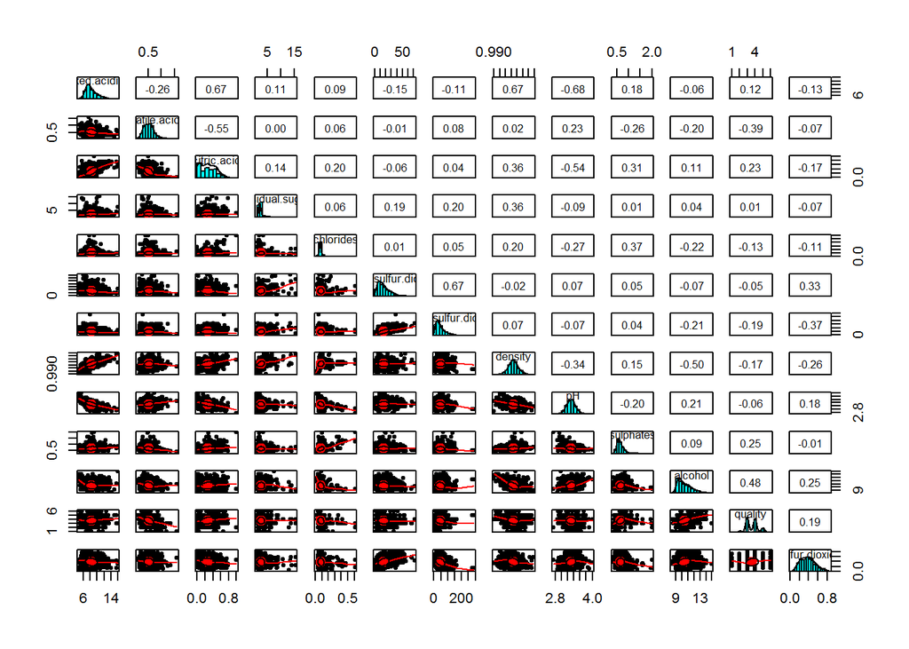

From the correlations, there is relatively high correlation between quality and both of alcohol and volatile.acidity Even though the quality is categorical variable and correlation may not be meaningful in this context as the many and diverse values of the quantitave variable maps to just a small set of the categorical variables. Also there is high correlation between pH and citric.acid and fixed.acidity and we can reflect on the correlation between pH and fixed.acidity from the squashed shape of the correlation ellipse, similar shape evident between density and fixed.acidity, also alcohol and density. free and total sulfur.dioxide seem highly correlated, too

## Alcohol and quality

```
## # A tibble: 6 x 4
##   quality mean_alcohol median_alcohol     n
##   <ord>          <dbl>          <dbl> <int>
## 1 3               9.96           9.93    10
## 2 4              10.3           10       53
## 3 5               9.90           9.7    681
## 4 6              10.6           10.5    638
## 5 7              11.5           11.5    199
## 6 8              12.1           12.2     18
```

At quality 4, the second lowest quality, the median_alcohol is less than the mean, then as quality increases we can see that the gap between median and mean closes in till the median_alcohol is higher than the mean at quality 7 and 8. So there is probably distribution changes along with those summaries for everyone of those quality which we’ll furhter investigate

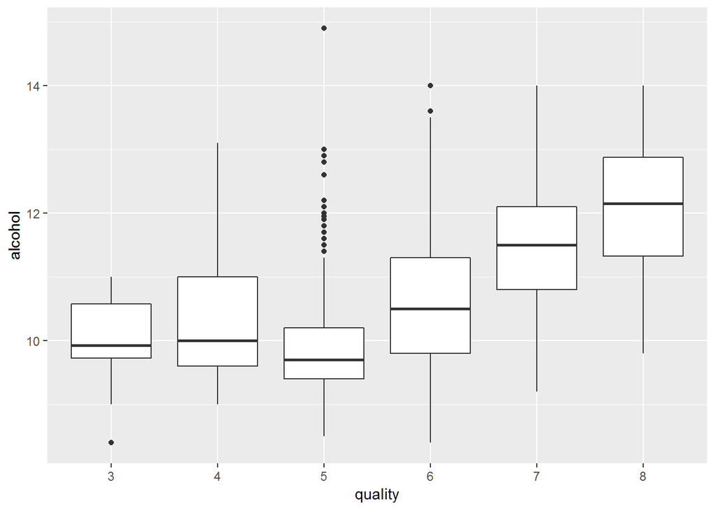

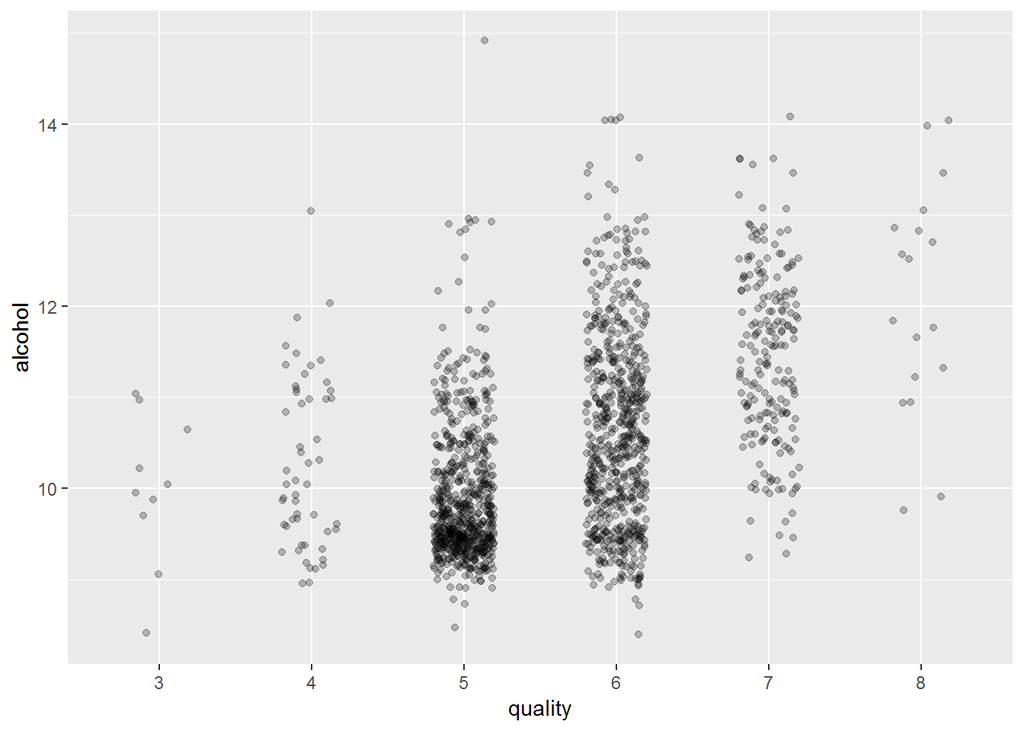

From the boxplot, we observe that from quality 5 up, it seems that the alcohol content increased in a steady way as quality increases. Comparing qualities 5,6,7, we can see in quality 5, dark regions concentrates on low alcohol content. In quality 6, those dark regions seems to like stretched upward to include more alcohol content. In quality 7, it’s obvious that the plot moves upwards compared to 5, 6, so alcohol obviously has some degree in increasing quality, but I may iterate on this observing histograms for each quality

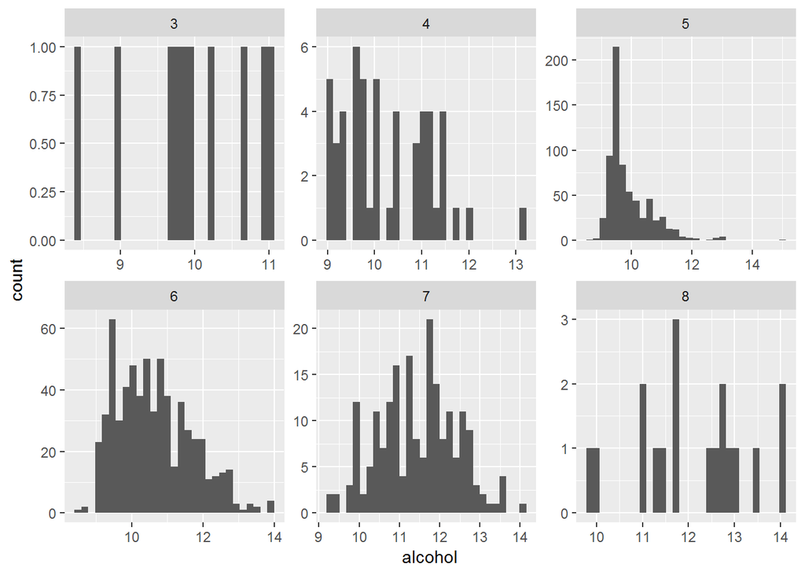

```
## # A tibble: 6 x 2
##   quality quality_n
##   <ord>       <int>
## 1 3              10
## 2 4              53
## 3 5             681
## 4 6             638
## 5 7             199
## 6 8              18
```

Examining the distributions of alcohol for each quality, we can see the tendency of low alcohol content in low quality wines as evident by the left towering peak of the right skewed distribution of quality 5 where most alcohol levels are below 10%. Then, there is a left peak also for quality ‘6’ below 10% but its relative height with respect to its Distribution is low compared to the peak at quality 5 with respect to quality 5 Dist . We can see this pattern of Deminishing skewness and translation of the peak of the distribution from left to right gradualy from quality 5 to 6. Finally, at quality 7, we see that the peak now around the center of the data, Almost no skewness in the distributions, but I should also point out the relatively low number of quality 7 ratings compared to 5 and 6, but 199 observations is sufficient for this small dataset of 1599 obs. In addition, it’s not easy to get a median of high quality 7 tested by various experts

I don’t put much concentration on quality 3, 4 and 8 distributions as the number of observations is very small to interpret the data, but for quality 3, 4 the distributions concentrate at relatively low alcohol content areas [8.5, 11], [9, 13] with bulk of data between [9, 11.5] while quality 8 covers range from [10, 14] with concentration with the bulk of the data between [11, 13]

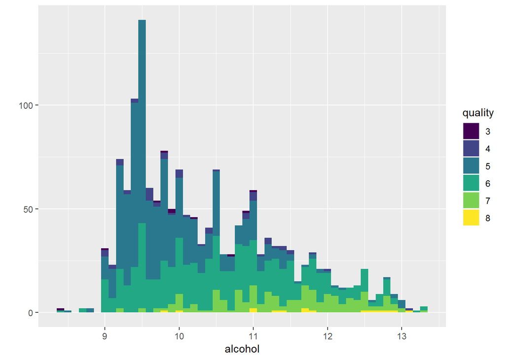

after color coding alchohol by quality, The distribution summarizes the insights that most of high quality wines have medium to high alcohol content. As we see the dark blueish low quality regions deminish by increasing the alcohol content while the yellow and greenish high quality regions become dominant at the same time.

## sulfur.dioxides

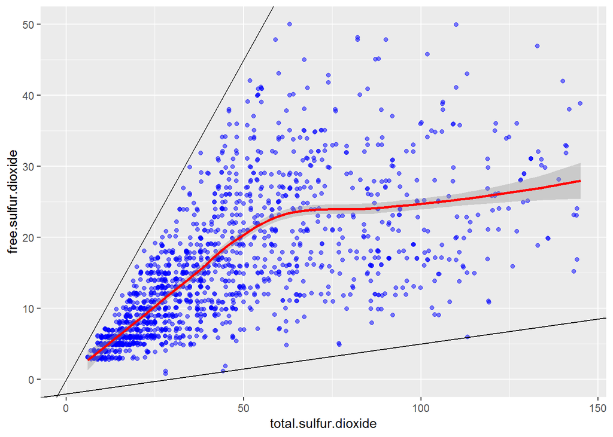

```
## FSO2 & TSO2 correlation:  0.6676665
```

For low concentrations of total.sulfur.dioxide below 50 and free.sulur.dioxide below 20, it seems their relations is almost linear, but we can see this relation no longer holds for higher concentration and the both of their points scatter almost non-uniformly in a way bounded by the cone shape depicted by the black boundary lines drawn in the plot

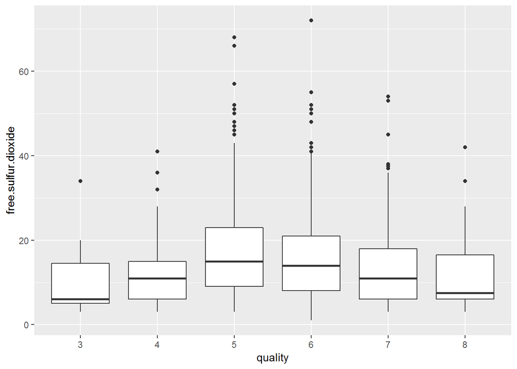

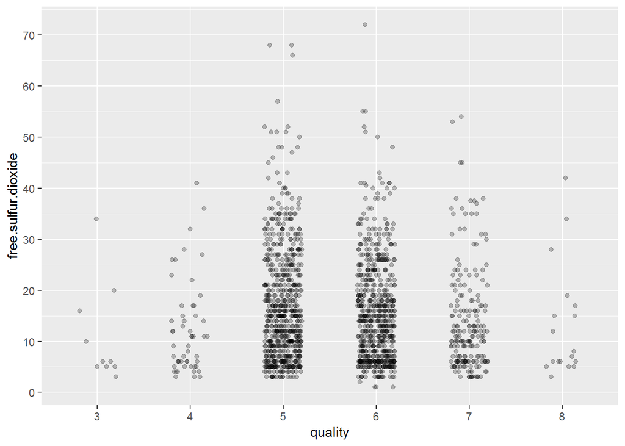

From quality 5 and higher, free.sulfur.dioxide concentrations decreases on average. We can notice that for quality 8, the highest free.sulfur concentration is around 40 below 50 as even though sulfur.dioxide is good for killing bacteria, its existence at high concentration becomes evident in the nose and taste of wine, but with a negative effect as shown by the boxplot.

We can also notice the similarity between quality 3 and 8 FSO2 boxplots. Taking in consideration both of the data counts is low (10 obs for quality 3, 18 obs for quality 8), there is might be another factor affecting the quality of wine behind the scenes. The problem about their low counts is that with any additional obs added to either 3, 8, their data summaries (mean, median) and shape may change drastically and that’s probably the reason why we can’t generalize from very small obs except with more sophisticated statistical procedures.

Observing the free.sulfur.dioxide scatter plot, it seems that there are certain concentratons favorable in the industry .e.g. the 5, 10, 15 mg/dm^3 concentrations for quality ‘5’ and the 5, 15 mg/dm^3 for quality ‘6’ and the 5, 10 mg/dm^3 for quality 7

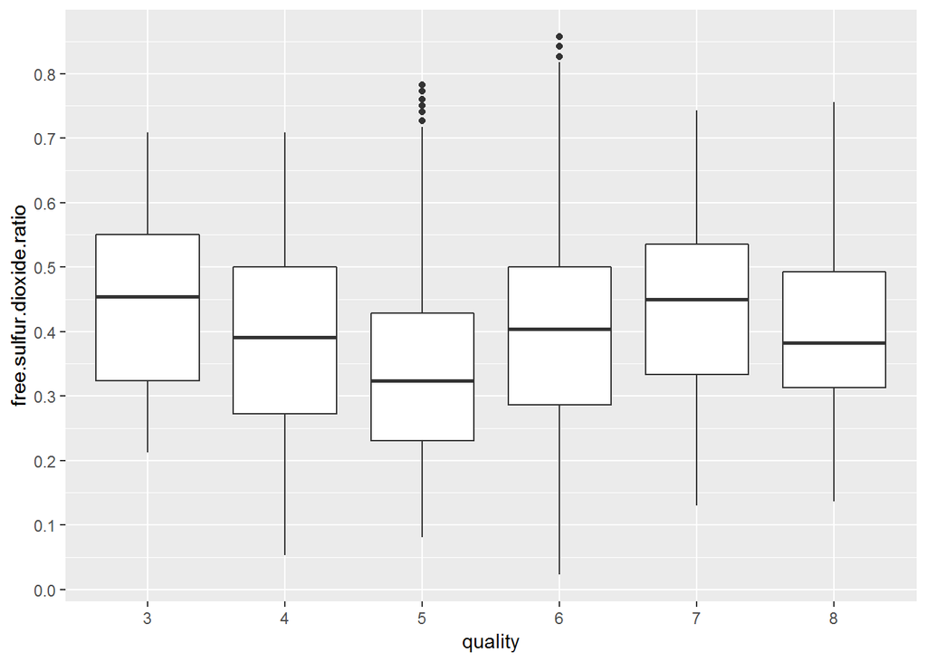

The ratio boxplots seem complex to intepret as low qualities 3, 4 seem to have high FSO2 ratios, quality seems to improve as ratio increases for qualities 5, 6, 7 and then quality 8 drops this pattern.

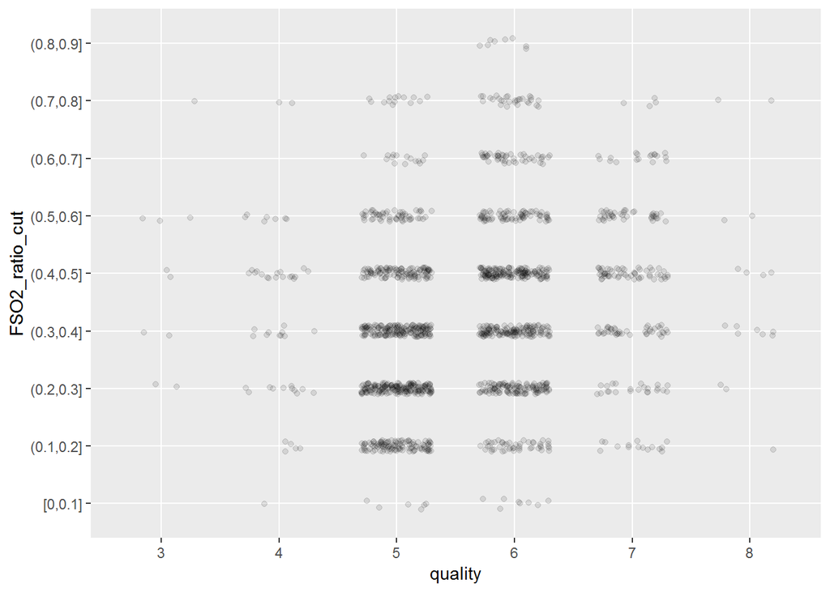

Observing the ratio cut, it’s clear now that there is certain ratios buckets favorable over others for each quality. For example quality 5 common FSO2 ratios are between .1 and .5 while quality 6 between .2 and .6. For quality 7, between .3 and .6

## Acids Explorations

```
##  Any 0 concentration of fixed.acidity:  FALSE
##  Is there a citry.acid concentration higher than fixed.acidity:  FALSE
```

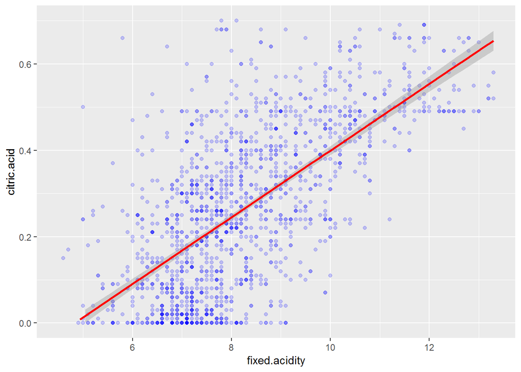

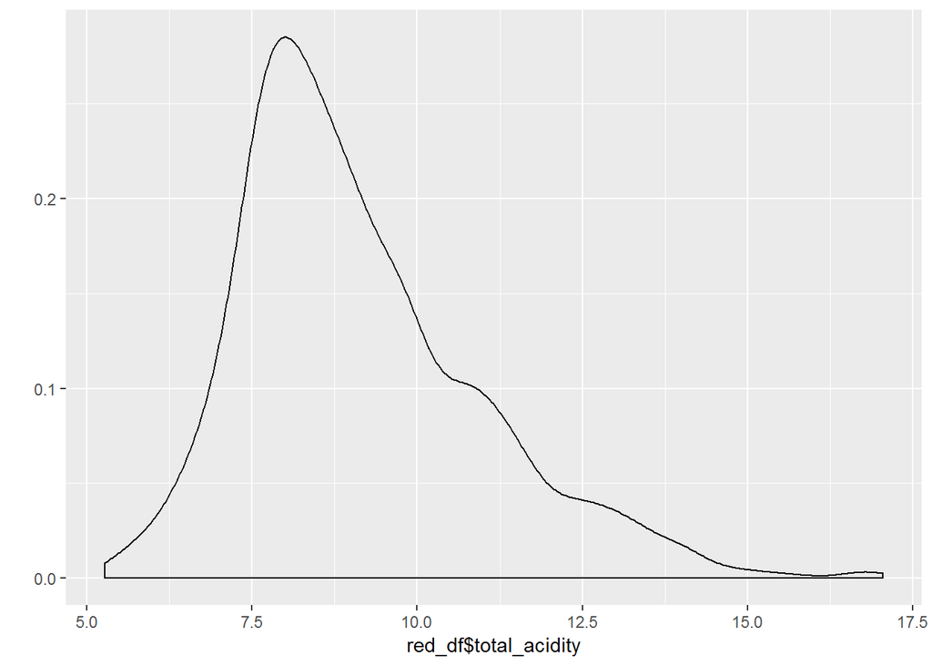

[figure not shown]

[output not shown]

```r
red_df$total_acidity = red_df$fixed.acidity + red_df$volatile.acidity + red_df$citric.acid


qplot(red_df$total_acidity, geom = 'density')
```

Fixed.acidity, citric acids contributes greatly to the pH level in the wine, the volatile.acidity as acetic acids contribute the least with a positive correlation coef of 0.23 aligning with categorization of aceticacids in chemistry as weak acids so that may relatively increase the pH value and we can see that the correlation absolute value of pH slighty increased withtotal.acidity -0.6834838 over only fixed.acidity -0.6829782 and the negative sign means that that they lower the pH value (increasing acidity)

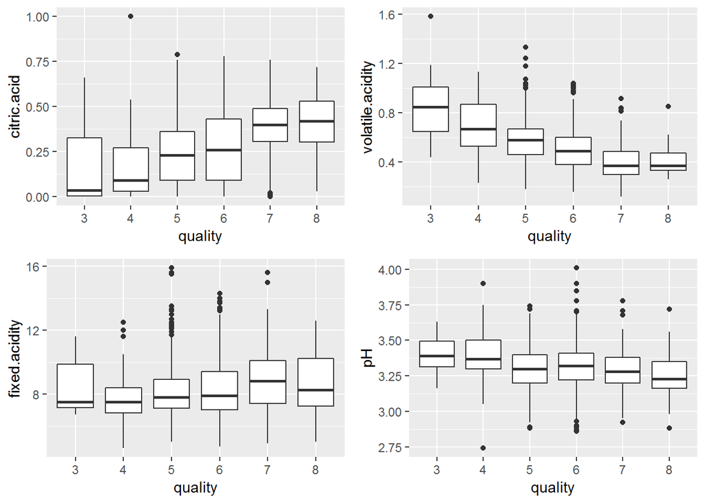

Observing the bulk of the data concentrated in the boxes in the boxplots:

1. For citric acids, High quality wines tend to have higher content of citric acid compared to lower quality.
2. For volatile.acidity, quality increases with lower concentrations of volatile acids. So, volatile acids may be undesirable in red wines.
3. For fixed.acidity, quality and fixd.acidity from the box plots seems to be unclear, fixed.acidity median may very slightly increase as quality increases from 4 to 7, but such increase isn’t significiant.
4. Summarizing all acids contributions in general, the pH effect seems neuteral on qualities 5 to 8, but we can notice that higher quality tend to be less than 3.5 and higher than than 3.125

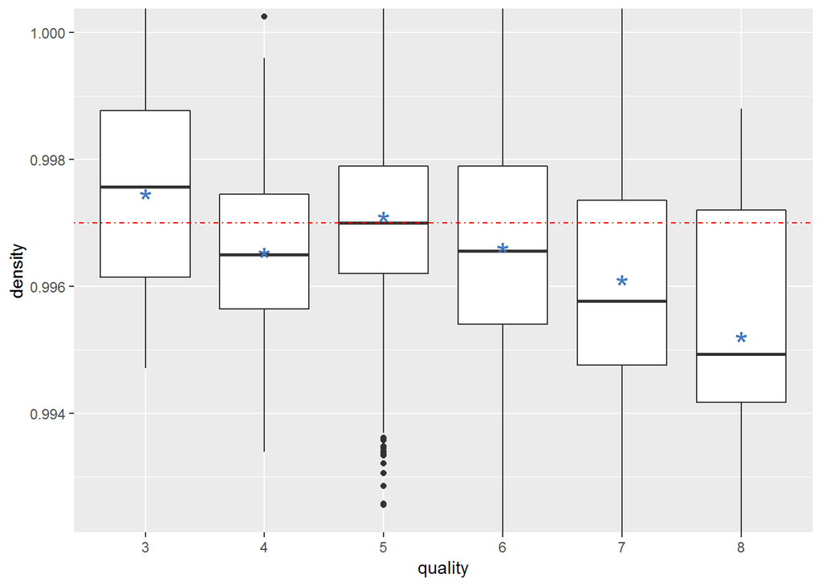

Density median tend to decrease as quality incerases evident from qualities of 5 upward and compared to water density(the red horizontal line) we can say that the median or mean density of wines tend to be around water density or less.

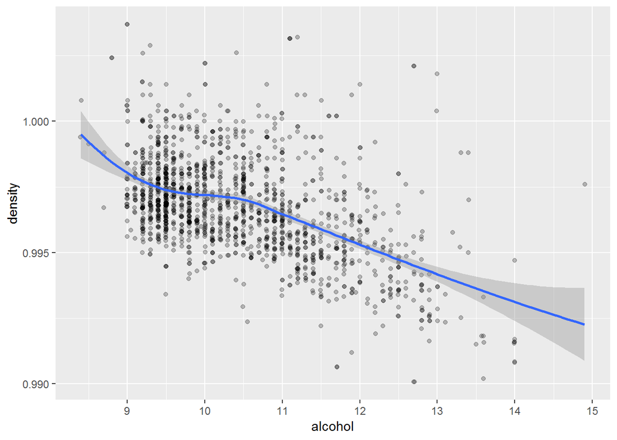

```
## Alcohol $ Wine Density correlation:  -0.4961798
```

As Alcohol concentration increases, the density of wine decreases and that evident by the -.5 correlatoin coefficient. That doesn’t come as a surprise as ethanol (alcohol) density is about 0.789 g/cm³, so having more alcohol content would attract higher density solution down to .789, but since wine doesn’t contain only alcohol, there are other factors affecting density That’s probably why the points like the one at density .995 g/cm^3 above the blue fit line at 14% alcohol concentration, so the other factors combined seem to increase the wine density in contrast to alcohol

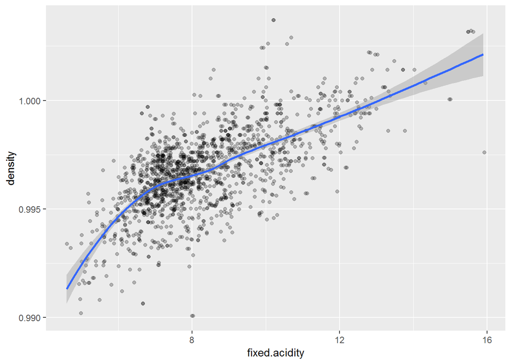

As fixed.acidity increases the density increases and by the previous box plot, when the density increases, it’s likely that the quality may decrease. but fixed.acidity also lowers ph of the wine which and we know that pH of wines concentrate between 3.25 and 3.5. So, it seems fixed.acidity is a critical feature very likely a causal one in affecting wine and wine characteristics, so there should be caution on controlling the fixed.acidity levels.

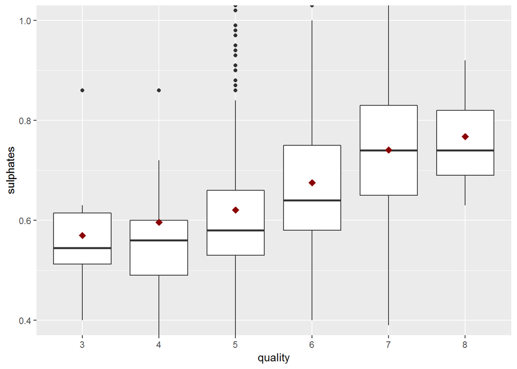

quality increases on average with sulpahtes content, for data of quality 4, it seems that the mean is pushed up due to some value outliers. For quality 7, the mean is nearly superimposed on the median

# Bivariate Analysis

### Talk about some of the relationships you observed in this part of the investigation. How did the feature(s) of interest vary with other features in the dataset?

- The alcohol content affects the quality substantially, as for the most stable data of quality 5, 6, 7, the alcohol content median and average increases as the quality increases.
- As essential as free.sulfur.dioxide is, high concentrations become evident in nose and taste, but this seems to negatively affect the quality through the analysis of quality and free.sulfur.dioxide.
- High Quality wines pH levels are around 3.25.

### Did you observe any interesting relationships between the other features (not the main feature(s) of interest)?

- Free and total sulfur dioxide, with a correlation coefficient of .67, total sulfur dioxide may give a good indication of the concentration of free.sulfur dioxide.
- Fixed acidity plays a crucial role in determining wine density, pH value where both in turn affect wine quality.
- Alcohol decreases wine density.

### What was the strongest relationship you found?

With -0.6829782 correlation coefficient, pH and fixed.acidity is the strongest relation and it’s also a causal relation as acids chemically lowers the pH value.

# Multivariate Plots Section

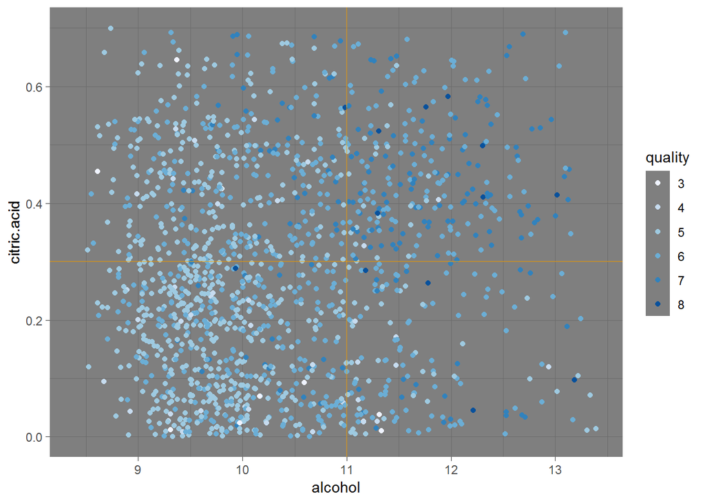

White and Light blue (low qulaity) wines concentrated on the low alcohol, low citric acide region quadrant. As either alcohol content increases or citric.acid increases, quality improves manifested by the dark blueish point regions to reach highest quality regions in the top far right high alcohol, high citric.acid quadrant

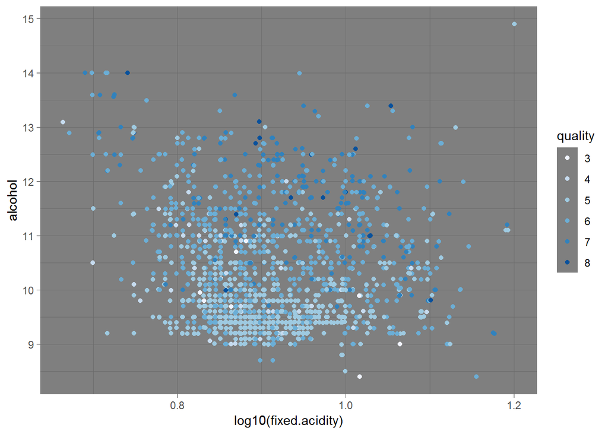

For low alcohol contenet, quality tend to be low or low-to-medium irrespective of fixed.acidity. There are horizontal alcohol stripes (.e.g. the strip immediately below 9.5 % alcohol, one at 10) which shows some alcohol concentration are more favorable than others.

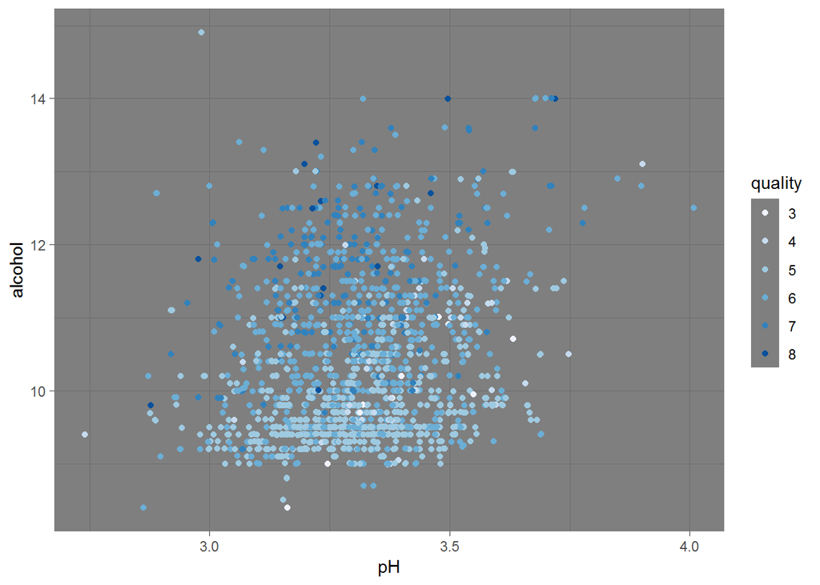

Observing the dark(high quality) and light(low quality)regions, light regions initiates at low level of alcohol and from the right bottom corner of the graph there is a trend where regions gets darker (higher quality) as we move diagonally from the bottom right corner (high pH, low alcohol) to the top left corner (low pH ‘higher acidity’, high alcohol)

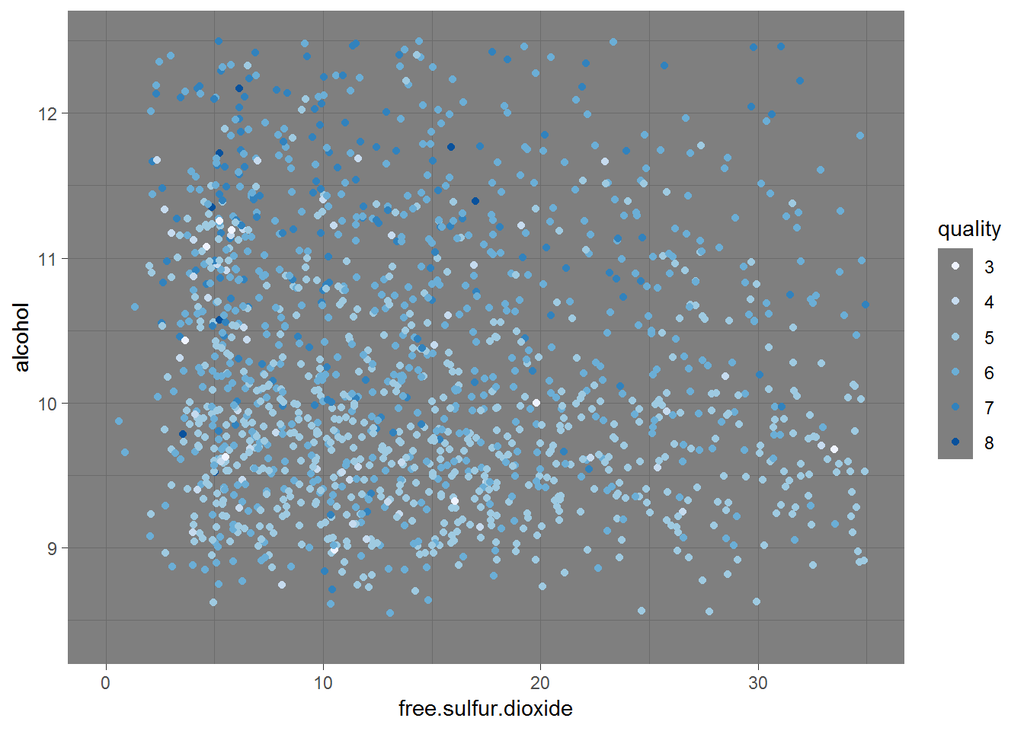

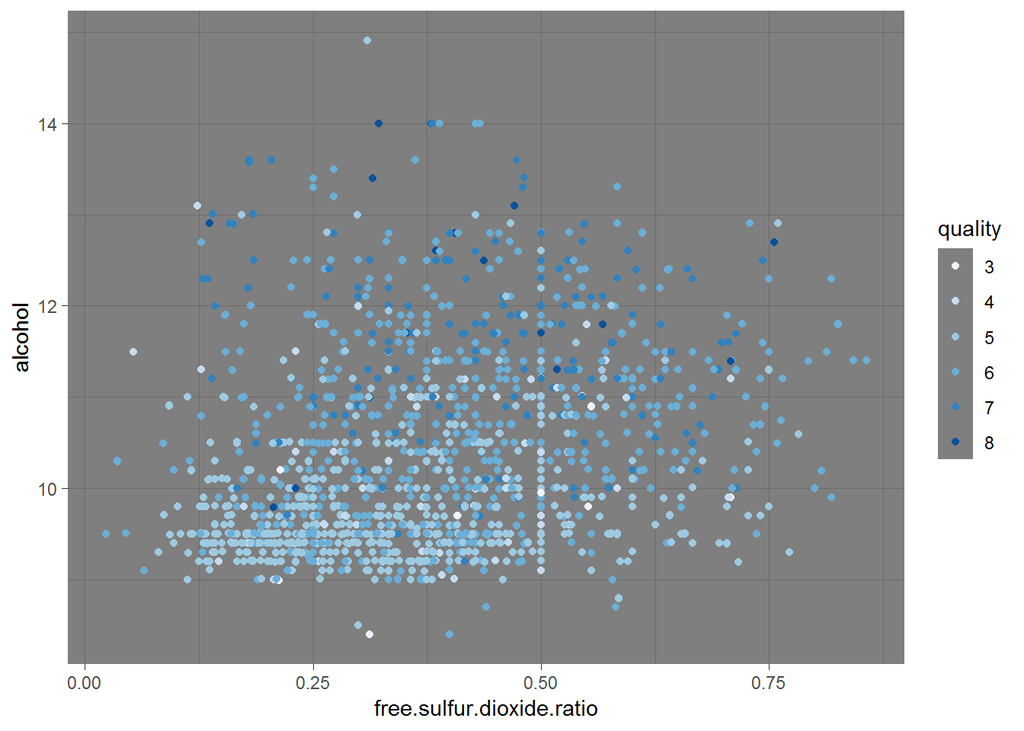

There are obvious bias in free.sulfur.dioxide.ratio and alcohol values manifested by the horizontal and vertical stripes like at FSO2.ratio of .5 or 10.5% alcohol.

For every FSO2.ratio vertical stripe, wine quality increases as alcohol increases while for every horizontal alcohol stripe, quality seems to be invariant to FSO2.ratio.

# Multivariate Analysis

### Talk about some of the relationships you observed in this part of the investigation. Were there features that strengthened each other in terms of looking at your feature(s) of interest?

citric.acid and alcohol go hand in hand with strenghting wine quality demonstrated by the scatter plot high quality regions in the top right quadrant.

pH and alcohol strenghen the quality in non-uniform way rather in diagnoally fashion from low alcohol, high pH to high alcohol, low pH and I stress diagnoally as there is high pH, low alcohol and low pH, low alcohol high quality regions

### Were there any interesting or surprising interactions between features?

FSO2 ratio and alcohol as FSO2 ratio seems to be invariant to quality, the only one playing role in quality is alcohol irrespective of FSO2 ratio, so high FSO2 concentration with enough alcohol may not denegrade the quality

### OPTIONAL: Did you create any models with your dataset? Discuss the strengths and limitations of your model.

No

# Final Plots and Summary

### Plot One

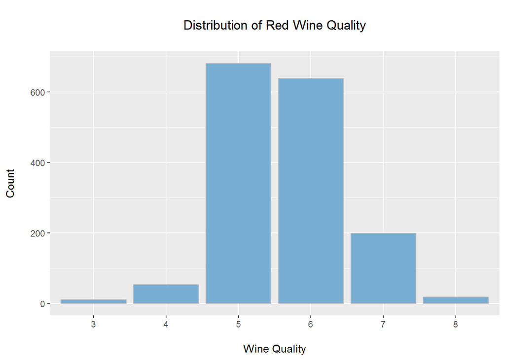

### Description One

The histogram shows the distribution of the wine quality in the red wine dataset with the quality rating in the x-axis and the count of the ratings at the y-axis.

Understanding the quailty distribution is crucial as: * Quality is main feature of interest in the data-set. * Although quality has possible values from 0 to 10. Our dataset quality rates are limited to only 3 to 8 with most of the concentrations limited to 5-7 and that happened possible due to reasons: 1. When returning to the data set provided, it appears that quality is median of at least 3 evaluations made by wine experts, and since every observation is a median, that may explain the high concentrations in mid-quality ratings 5,6 2. The data set is relatively small of only 1599 observations.

### Plot Two

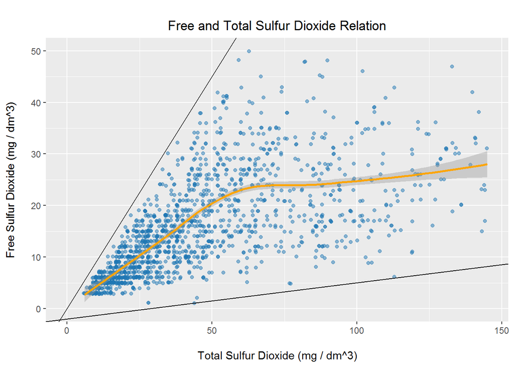

### Description Two

The scatter plot shows the relation between Total Sulfur Dioxide TSO2 (mg / dm^3) on the x-axis and the Free Sulfur Dioxide FSO2 (mg / dm^3) on the y-axis and an orange fit line to the relation.

For low concentrations of total.sulfur.dioxide below 50 and free.sulur.dioxide below 20, it seems their relations is almost linear, but we can see this relation no longer holds for higher concentration and the both of their points scatter almost non-uniformly in a way bounded by the cone shape depicted by the black boundary lines drawn in the plot, but as the fit orange line shows for those high values of Total Sulfur dioxide, the free sulfur dioxide reaches some form of saturations as it doesn’t increase much while total Sulfur dioxide increases.

Researching the topic, it appears that manifactures supply wines with free sulfur dioxide to kill bacteria, but some of the FSO2 bind with other components, becoming bound sulfur dioxide which contributes to the total sulfur dioxide, but under bound SO2 not free SO2 and that explains the saturation at the end of the graph as manufacturers probably want specific concentration of FSO2 and in some wines, more FSO2 atoms bind with other wine components, necessitating adding more FSO2, leaving TSO2 levels high

### Plot Three

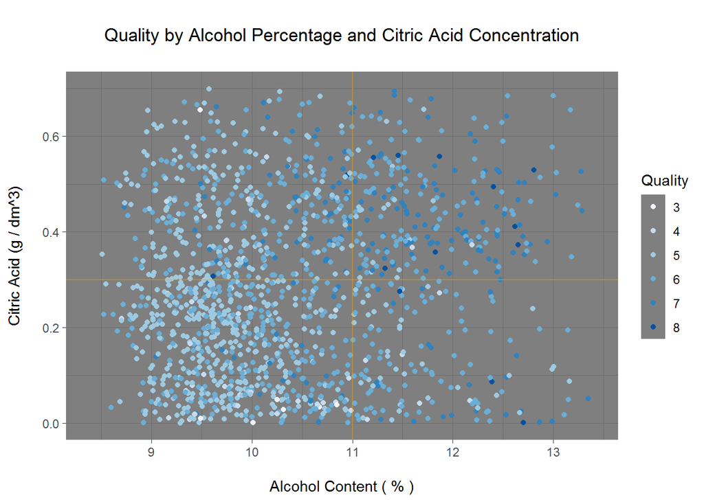

### Description Three

A scatter plot between alcohol percentage and citric acid concentration (g/ dm^3) in the red wine samples, color coded by quality.

From the plot citric.acid and alcohol go hand in hand with strenghting ed wine quality as white, Light blue regions (low qulaity wines) concentrated on the low alcohol, low citric acid region quadrant. As either alcohol content increases or citric.acid increases, quality improves manifested by the dark blueish regions to reach highest density regions of high quality in the top far right high alcohol, high citric.acid quadrant

# Reflection

- The odd distribution of red wine quality as data represents median values, so some quality ratings like 5, 6 are dominant in terms of count. Median values makes the analysis harder because it biases the distribution of quality. I would rather prefer one of two options:
  - Supplying every single quality rating along with the expert id, in this case we may consider different summaries to quality, and will probably find out what affects every expert rating. In addition, according the data set provider every observation quality is median of at least 3 experts, so every observation probably wans’t rated according to the same experts or the same number of experts
  - Supplying more observations, the insufficiency of observations provides insufficiency of ratings two as evident for quality 3, 4, and 8, very few observations fall into those qualitites.
- Red wines pH values concentrates between 3.125 and 3.5 with most at 3.375, pH values are important because they are one major cause for red wine ‘red’ color.
- Free sulfur dioxide and total sulfur dioxide related concentrations, and the saturation of free sulfur dioxide levels at some values around 20-30 mg/dm^3
- Although FSO2 concentrattion and ratio may be evident at nose and smell, for not very high concentration around 30 mg/dm^3, supplying the right amount of alcohol to the red wine surprisingly covers the FSO2 effect. That alone shows the importance of alcohol in wines. Actually wines are about alcohol.
- For future analysis, I suggest searching the effect of sulpahtes and FSO2. Also, the residual.sugar most concentrations are less than 4 g/dm^3 and the max residual sugar concentration is less than 16 g/dm^3, so there is no observations to test sweet red wines with residual sugar concentration near 45 g/dm^3

# Citation

This dataset is public available for research. The details are described in [Cortez et al., 2009]. Please include this citation if you plan to use this database:

P. Cortez, A. Cerdeira, F. Almeida, T. Matos and J. Reis. Modeling wine preferences by data mining from physicochemical properties. In Decision Support Systems, Elsevier, 47(4):547-553. ISSN: 0167-9236.

Available at: [@Elsevier] http://dx.doi.org/10.1016/j.dss.2009.05.016 [Pre-press (pdf)] http://www3.dsi.uminho.pt/pcortez/winequality09.pdf [bib] http://www3.dsi.uminho.pt/pcortez/dss09.bib

# Resources

- [Potassium Metabisulfite Additions](https://winemakersacademy.com/potassium-metabisulfite-additions/)
- [Fixed Acidity](https://waterhouse.ucdavis.edu/whats-in-wine/fixed-acidity%5D)
- [Total sulfur dioxide. Why it matters](https://www.extension.iastate.edu/wine/total-sulfur-dioxide-why-it-matters-too)